# How Data Can Allow Us to Predict a Starbucks Customer's Response to an Offer

# Data Cleanup + Pre-processing

Let's start with some cleanup

## 1. Profile Dataset

```python
profile_copy=profile.copy()
```

```python
profile_copy.head()
```

|  | age | became_member_on | gender | id | income |
| --- | --- | --- | --- | --- | --- |
| 0 | 118 | 20170212 | None | 68be06ca386d4c31939f3a4f0e3dd783 | NaN |
| 1 | 55 | 20170715 | F | 0610b486422d4921ae7d2bf64640c50b | 112000.0 |
| 2 | 118 | 20180712 | None | 38fe809add3b4fcf9315a9694bb96ff5 | NaN |
| 3 | 75 | 20170509 | F | 78afa995795e4d85b5d9ceeca43f5fef | 100000.0 |
| 4 | 118 | 20170804 | None | a03223e636434f42ac4c3df47e8bac43 | NaN |

```python
# rename columns
new_col_names = {'id':'customer_id' , 'income':'customer_income', 'gender':'customer_gender', 'age': 'customer_age'}
profile_copy = profile_copy.rename(new_col_names, axis=1)
```

Let's start by changing the format of the "became_member_on" field. it's a bit hard to read

```python
profile_copy['became_member_on'] = pd.to_datetime(profile_copy['became_member_on'], format='%Y%m%d')
profile_copy['became_member_on'].head(1)
```

```
0   2017-02-12
Name: became_member_on, dtype: datetime64[ns]
```

```python
#check for different age values
profile_copy.customer_age.value_counts()
```

```
118    2175
58      408
53      372
51      363
54      359
59      359
57      353
52      351
55      350
56      342
63      338
60      333
49      321
62      318
67      317
```

[output cut: 47 more lines]

weird...there's a lot of people who are 118 years old... perhaps According to the description of the profile data frame and checking null values, it looks like values of gender & income are missing where age is 118. Let's confirm this.

```python
profile_copy[profile_copy['customer_age']== 118].drop(['became_member_on' ,'customer_id'], axis=1)
```

|  | customer_age | customer_gender | customer_income |
| --- | --- | --- | --- |
| 0 | 118 | None | NaN |
| 2 | 118 | None | NaN |
| 4 | 118 | None | NaN |
| 6 | 118 | None | NaN |
| 7 | 118 | None | NaN |
| 9 | 118 | None | NaN |
| 10 | 118 | None | NaN |
| 11 | 118 | None | NaN |
| 17 | 118 | None | NaN |
| 23 | 118 | None | NaN |
| 26 | 118 | None | NaN |
| 36 | 118 | None | NaN |
| 39 | 118 | None | NaN |
| 44 | 118 | None | NaN |
| 45 | 118 | None | NaN |
| 54 | 118 | None | NaN |
| 56 | 118 | None | NaN |
| 57 | 118 | None | NaN |
| 80 | 118 | None | NaN |
| 84 | 118 | None | NaN |
| 96 | 118 | None | NaN |
| 103 | 118 | None | NaN |
| 104 | 118 | None | NaN |
| 108 | 118 | None | NaN |
| 121 | 118 | None | NaN |
| 122 | 118 | None | NaN |
| 128 | 118 | None | NaN |
| 143 | 118 | None | NaN |
| 169 | 118 | None | NaN |
| 172 | 118 | None | NaN |
| ... | ... | ... | ... |
| 16820 | 118 | None | NaN |
| 16829 | 118 | None | NaN |
| 16831 | 118 | None | NaN |
| 16835 | 118 | None | NaN |
| 16839 | 118 | None | NaN |
| 16842 | 118 | None | NaN |
| 16844 | 118 | None | NaN |
| 16845 | 118 | None | NaN |
| 16852 | 118 | None | NaN |
| 16853 | 118 | None | NaN |
| 16856 | 118 | None | NaN |
| 16861 | 118 | None | NaN |
| 16869 | 118 | None | NaN |
| 16875 | 118 | None | NaN |
| 16877 | 118 | None | NaN |
| 16885 | 118 | None | NaN |
| 16906 | 118 | None | NaN |
| 16915 | 118 | None | NaN |
| 16923 | 118 | None | NaN |
| 16931 | 118 | None | NaN |
| 16942 | 118 | None | NaN |
| 16951 | 118 | None | NaN |
| 16953 | 118 | None | NaN |
| 16969 | 118 | None | NaN |
| 16977 | 118 | None | NaN |
| 16980 | 118 | None | NaN |
| 16982 | 118 | None | NaN |
| 16989 | 118 | None | NaN |
| 16991 | 118 | None | NaN |
| 16994 | 118 | None | NaN |

2175 rows × 3 columns

Suspicion was correct....Let's replace these ages with NULL and then impute the null ages with the mean age. Using the mean age will be a little more expressive

```python
profile_copy.replace(118, np.nan , inplace=True)
profile_copy['customer_age'] = profile_copy['customer_age'].fillna(profile_copy['customer_age'].mean())
```

Since we also observed null values for customer income, let's impute the missing values with the income mean

```python
profile_copy['customer_income'] = profile_copy['customer_income'].fillna(profile_copy['customer_income'].mean())
```

What should we do with the null genders? The most sensible thing to do would be to impute those values with the mode

```python
mode = profile_copy['customer_gender'].mode()[0]
profile_copy['customer_gender'] = profile_copy['customer_gender'].fillna(mode)
profile_copy['customer_gender'] = profile_copy['customer_gender'].replace('O', mode)
```

Let's take a look at the age distribution again

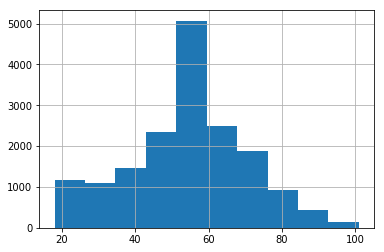

```python
profile_copy.customer_age.hist();
```

As aforementioned, we have a large age range, so let's bucketize these ages into categories to reduce noise during the learning process

```python
profile_copy.loc[(profile_copy.customer_age < 20) , 'Age_Group'] = 'Under 20'
profile_copy.loc[(profile_copy.customer_age >= 20) & (profile_copy.customer_age <= 45) , 'Age_Group'] = '20-45'
profile_copy.loc[(profile_copy.customer_age >= 46) & (profile_copy.customer_age <= 60) , 'Age_Group'] = '46-60'
profile_copy.loc[(profile_copy.customer_age >= 61) , 'Age_Group'] = '61-80'
profile_copy.drop('customer_age',axis=1,inplace=True)
```

```python
cleaned_profile = profile_copy
```

## 2. Portfolio Dataset

```python
portfolio_copy = portfolio.copy(deep=True)
portfolio_copy.head()
```

|  | channels | difficulty | duration | id | offer_type | reward |
| --- | --- | --- | --- | --- | --- | --- |
| 0 | [email, mobile, social] | 10 | 7 | ae264e3637204a6fb9bb56bc8210ddfd | bogo | 10 |
| 1 | [web, email, mobile, social] | 10 | 5 | 4d5c57ea9a6940dd891ad53e9dbe8da0 | bogo | 10 |
| 2 | [web, email, mobile] | 0 | 4 | 3f207df678b143eea3cee63160fa8bed | informational | 0 |
| 3 | [web, email, mobile] | 5 | 7 | 9b98b8c7a33c4b65b9aebfe6a799e6d9 | bogo | 5 |
| 4 | [web, email] | 20 | 10 | 0b1e1539f2cc45b7b9fa7c272da2e1d7 | discount | 5 |

```python
#rename columns
new_col_names = {'difficulty':'offer_difficulty' , 'id':'offer_id', 'duration':'offer_duration', 'reward': 'offer_reward'}
portfolio_copy = portfolio_copy.rename(new_col_names, axis=1)
```

```python
channels_exploded = pd.get_dummies(portfolio_copy['channels'].apply(pd.Series).stack()).sum(level=0)
```

```python
portfolio_copy = pd.concat([portfolio_copy, channels_exploded], axis=1)

portfolio_copy.head()
```

|  | channels | offer_difficulty | offer_duration | offer_id | offer_type | offer_reward | email | mobile | social | web |
| --- | --- | --- | --- | --- | --- | --- | --- | --- | --- | --- |
| 0 | [email, mobile, social] | 10 | 7 | ae264e3637204a6fb9bb56bc8210ddfd | bogo | 10 | 1 | 1 | 1 | 0 |
| 1 | [web, email, mobile, social] | 10 | 5 | 4d5c57ea9a6940dd891ad53e9dbe8da0 | bogo | 10 | 1 | 1 | 1 | 1 |
| 2 | [web, email, mobile] | 0 | 4 | 3f207df678b143eea3cee63160fa8bed | informational | 0 | 1 | 1 | 0 | 1 |
| 3 | [web, email, mobile] | 5 | 7 | 9b98b8c7a33c4b65b9aebfe6a799e6d9 | bogo | 5 | 1 | 1 | 0 | 1 |
| 4 | [web, email] | 20 | 10 | 0b1e1539f2cc45b7b9fa7c272da2e1d7 | discount | 5 | 1 | 0 | 0 | 1 |

```python
offer_type_exploded = pd.get_dummies(portfolio_copy['offer_type'].apply(pd.Series).stack()).sum(level=0)
offer_type_exploded.head()
```

|  | bogo | discount | informational |
| --- | --- | --- | --- |
| 0 | 1 | 0 | 0 |
| 1 | 1 | 0 | 0 |
| 2 | 0 | 0 | 1 |
| 3 | 1 | 0 | 0 |
| 4 | 0 | 1 | 0 |

```python
portfolio_copy = pd.concat([portfolio_copy, offer_type_exploded], axis=1)

portfolio_copy.head()
```

|  | channels | offer_difficulty | offer_duration | offer_id | offer_type | offer_reward | email | mobile | social | web | bogo | discount | informational |
| --- | --- | --- | --- | --- | --- | --- | --- | --- | --- | --- | --- | --- | --- |
| 0 | [email, mobile, social] | 10 | 7 | ae264e3637204a6fb9bb56bc8210ddfd | bogo | 10 | 1 | 1 | 1 | 0 | 1 | 0 | 0 |
| 1 | [web, email, mobile, social] | 10 | 5 | 4d5c57ea9a6940dd891ad53e9dbe8da0 | bogo | 10 | 1 | 1 | 1 | 1 | 1 | 0 | 0 |
| 2 | [web, email, mobile] | 0 | 4 | 3f207df678b143eea3cee63160fa8bed | informational | 0 | 1 | 1 | 0 | 1 | 0 | 0 | 1 |
| 3 | [web, email, mobile] | 5 | 7 | 9b98b8c7a33c4b65b9aebfe6a799e6d9 | bogo | 5 | 1 | 1 | 0 | 1 | 1 | 0 | 0 |
| 4 | [web, email] | 20 | 10 | 0b1e1539f2cc45b7b9fa7c272da2e1d7 | discount | 5 | 1 | 0 | 0 | 1 | 0 | 1 | 0 |

```python
cleaned_portfolio = portfolio_copy
```

## 3. Transcript Dataset

```python
transcript_copy = transcript.copy(deep=True)
```

```python
transcript_copy.head()
```

|  | event | person | time | value |
| --- | --- | --- | --- | --- |
| 0 | offer received | 78afa995795e4d85b5d9ceeca43f5fef | 0 | {'offer id': '9b98b8c7a33c4b65b9aebfe6a799e6d9'} |
| 1 | offer received | a03223e636434f42ac4c3df47e8bac43 | 0 | {'offer id': '0b1e1539f2cc45b7b9fa7c272da2e1d7'} |
| 2 | offer received | e2127556f4f64592b11af22de27a7932 | 0 | {'offer id': '2906b810c7d4411798c6938adc9daaa5'} |
| 3 | offer received | 8ec6ce2a7e7949b1bf142def7d0e0586 | 0 | {'offer id': 'fafdcd668e3743c1bb461111dcafc2a4'} |
| 4 | offer received | 68617ca6246f4fbc85e91a2a49552598 | 0 | {'offer id': '4d5c57ea9a6940dd891ad53e9dbe8da0'} |

```python
#rename columns
new_col_names = {'person':'customer_id'}
transcript_copy = transcript_copy.rename(new_col_names, axis=1)
```

First, we need to pull out the contents of the value dictionary into separate columns

```python
transcript_copy = pd.concat([transcript_copy, transcript_copy['value'].apply(pd.Series)], axis=1)

# we don't need the dictionary anymore
transcript_copy.drop('value', axis=1, inplace=True)

transcript_copy.head()
```

|  | event | customer_id | time | offer id | amount | offer_id | reward |
| --- | --- | --- | --- | --- | --- | --- | --- |
| 0 | offer received | 78afa995795e4d85b5d9ceeca43f5fef | 0 | 9b98b8c7a33c4b65b9aebfe6a799e6d9 | NaN | NaN | NaN |
| 1 | offer received | a03223e636434f42ac4c3df47e8bac43 | 0 | 0b1e1539f2cc45b7b9fa7c272da2e1d7 | NaN | NaN | NaN |
| 2 | offer received | e2127556f4f64592b11af22de27a7932 | 0 | 2906b810c7d4411798c6938adc9daaa5 | NaN | NaN | NaN |
| 3 | offer received | 8ec6ce2a7e7949b1bf142def7d0e0586 | 0 | fafdcd668e3743c1bb461111dcafc2a4 | NaN | NaN | NaN |
| 4 | offer received | 68617ca6246f4fbc85e91a2a49552598 | 0 | 4d5c57ea9a6940dd891ad53e9dbe8da0 | NaN | NaN | NaN |

Let's do some encoding! Let's see whether integer encoding or one hot encoding will be more appropriate

```python
transcript_copy['event'].value_counts()
```

```
transaction        138953
offer received      76277
offer viewed        57725
offer completed     33579
Name: event, dtype: int64
```

Since we see a bit of an ordinal relationship amongst the different transcript events, we'll integer encode the values of this column

```python
transcript_copy['event'] = transcript_copy['event'].map({'offer received':1, 'offer viewed':2, 'offer completed':3, 'transaction':4})
```

```python
transcript_copy[transcript_copy['event']==3].head()
```

|  | event | customer_id | time | offer id | amount | offer_id | reward |
| --- | --- | --- | --- | --- | --- | --- | --- |
| 12658 | 3 | 9fa9ae8f57894cc9a3b8a9bbe0fc1b2f | 0 | NaN | NaN | 2906b810c7d4411798c6938adc9daaa5 | 2.0 |
| 12672 | 3 | fe97aa22dd3e48c8b143116a8403dd52 | 0 | NaN | NaN | fafdcd668e3743c1bb461111dcafc2a4 | 2.0 |
| 12679 | 3 | 629fc02d56414d91bca360decdfa9288 | 0 | NaN | NaN | 9b98b8c7a33c4b65b9aebfe6a799e6d9 | 5.0 |
| 12692 | 3 | 676506bad68e4161b9bbaffeb039626b | 0 | NaN | NaN | ae264e3637204a6fb9bb56bc8210ddfd | 10.0 |
| 12697 | 3 | 8f7dd3b2afe14c078eb4f6e6fe4ba97d | 0 | NaN | NaN | 4d5c57ea9a6940dd891ad53e9dbe8da0 | 10.0 |

It looks like the offer ids are populated weird

```python
transcript_copy['offer id'] = transcript_copy['offer id'].fillna(transcript_copy['offer_id'])
transcript_copy[transcript_copy['event']==3].head()
```

|  | event | customer_id | time | offer id | amount | offer_id | reward |
| --- | --- | --- | --- | --- | --- | --- | --- |
| 12658 | 3 | 9fa9ae8f57894cc9a3b8a9bbe0fc1b2f | 0 | 2906b810c7d4411798c6938adc9daaa5 | NaN | 2906b810c7d4411798c6938adc9daaa5 | 2.0 |
| 12672 | 3 | fe97aa22dd3e48c8b143116a8403dd52 | 0 | fafdcd668e3743c1bb461111dcafc2a4 | NaN | fafdcd668e3743c1bb461111dcafc2a4 | 2.0 |
| 12679 | 3 | 629fc02d56414d91bca360decdfa9288 | 0 | 9b98b8c7a33c4b65b9aebfe6a799e6d9 | NaN | 9b98b8c7a33c4b65b9aebfe6a799e6d9 | 5.0 |
| 12692 | 3 | 676506bad68e4161b9bbaffeb039626b | 0 | ae264e3637204a6fb9bb56bc8210ddfd | NaN | ae264e3637204a6fb9bb56bc8210ddfd | 10.0 |
| 12697 | 3 | 8f7dd3b2afe14c078eb4f6e6fe4ba97d | 0 | 4d5c57ea9a6940dd891ad53e9dbe8da0 | NaN | 4d5c57ea9a6940dd891ad53e9dbe8da0 | 10.0 |

```python
transcript_copy['amount'].value_counts()
```

```
0.05      431
0.66      166
1.18      165
1.01      163
0.90      161
1.23      161
0.50      159
0.53      159
1.19      159
0.79      157
1.50      156
0.92      156
1.54      155
0.70      154
0.74      154
1.57      154
1.22      153
1.27      153
1.16      152
0.67      152
0.94      152
0.65      152
0.84      152
1.13      151
1.32      150
0.86      150
1.02      150
0.91      150
1.20      150
1.33      149
         ...
65.02       1
38.52       1
39.29       1
120.08      1
597.91      1
115.00      1
48.43       1
49.03       1
83.03       1
703.57      1
76.24       1
553.18      1
840.28      1
41.21       1
92.30       1
87.71       1
45.76       1
841.06      1
48.54       1
943.40      1
74.77       1
267.69      1
74.64       1
736.35      1
65.43       1
650.75      1
55.42       1
43.77       1
47.23       1
53.40       1
Name: amount, Length: 5103, dtype: int64
```

Fixed it! This will save us from encountering problems when we join this dataset with another on offer id. Let's now remove the extraneous offer id field

```python
transcript_copy = transcript_copy.drop('offer_id', axis=1)
transcript_copy = transcript_copy.rename({'offer id':'offer_id'}, axis=1)
```

```python
cleaned_transcript = transcript_copy
```

```python
cleaned_transcript.head()
```

|  | event | customer_id | time | offer_id | amount | reward |
| --- | --- | --- | --- | --- | --- | --- |
| 0 | 1 | 78afa995795e4d85b5d9ceeca43f5fef | 0 | 9b98b8c7a33c4b65b9aebfe6a799e6d9 | NaN | NaN |
| 1 | 1 | a03223e636434f42ac4c3df47e8bac43 | 0 | 0b1e1539f2cc45b7b9fa7c272da2e1d7 | NaN | NaN |
| 2 | 1 | e2127556f4f64592b11af22de27a7932 | 0 | 2906b810c7d4411798c6938adc9daaa5 | NaN | NaN |
| 3 | 1 | 8ec6ce2a7e7949b1bf142def7d0e0586 | 0 | fafdcd668e3743c1bb461111dcafc2a4 | NaN | NaN |
| 4 | 1 | 68617ca6246f4fbc85e91a2a49552598 | 0 | 4d5c57ea9a6940dd891ad53e9dbe8da0 | NaN | NaN |

# EDA

Let's merge the three datasets and see what we can discover!

```python
def merge_data(portfolio,profile,transcript):
    """
    merge_data()
    Purpose: Merge cleaned data frames for EDA
    Inputs:
    - portfolio : cleaned portfolio dataframe
    - profile : cleaned profile dataframe
    - transcript : cleaned transcript dataframe

    Returns: a merged data frame
    """

    merged_df = pd.merge(portfolio, transcript, on='offer_id')
    merged_df = pd.merge(merged_df, profile, on='customer_id')

    return merged_df
```

```python
merged_df = merge_data(cleaned_portfolio, cleaned_profile, cleaned_transcript)
merged_df.head()
```

|  | channels | offer_difficulty | offer_duration | offer_id | offer_type | offer_reward | email | mobile | social | web | ... | informational | event | customer_id | time | amount | reward | became_member_on | customer_gender | customer_income | Age_Group |
| --- | --- | --- | --- | --- | --- | --- | --- | --- | --- | --- | --- | --- | --- | --- | --- | --- | --- | --- | --- | --- | --- |
| 0 | [email, mobile, social] | 10 | 7 | ae264e3637204a6fb9bb56bc8210ddfd | bogo | 10 | 1 | 1 | 1 | 0 | ... | 0 | 1 | 4b0da7e80e5945209a1fdddfe813dbe0 | 0 | NaN | NaN | 2017-09-09 | M | 100000.0 | 61-80 |
| 1 | [email, mobile, social] | 10 | 7 | ae264e3637204a6fb9bb56bc8210ddfd | bogo | 10 | 1 | 1 | 1 | 0 | ... | 0 | 2 | 4b0da7e80e5945209a1fdddfe813dbe0 | 102 | NaN | NaN | 2017-09-09 | M | 100000.0 | 61-80 |
| 2 | [email, mobile, social] | 10 | 7 | ae264e3637204a6fb9bb56bc8210ddfd | bogo | 10 | 1 | 1 | 1 | 0 | ... | 0 | 1 | 4b0da7e80e5945209a1fdddfe813dbe0 | 504 | NaN | NaN | 2017-09-09 | M | 100000.0 | 61-80 |
| 3 | [email, mobile, social] | 10 | 7 | ae264e3637204a6fb9bb56bc8210ddfd | bogo | 10 | 1 | 1 | 1 | 0 | ... | 0 | 2 | 4b0da7e80e5945209a1fdddfe813dbe0 | 510 | NaN | NaN | 2017-09-09 | M | 100000.0 | 61-80 |
| 4 | [email, mobile, social] | 10 | 7 | ae264e3637204a6fb9bb56bc8210ddfd | bogo | 10 | 1 | 1 | 1 | 0 | ... | 0 | 3 | 4b0da7e80e5945209a1fdddfe813dbe0 | 510 | NaN | 10.0 | 2017-09-09 | M | 100000.0 | 61-80 |

5 rows × 22 columns

First, let's look at the distribution of action taken based on age group

## Question 1: Which age group took the most advantage of the offers?

Event Key:

1 = Offer Received

2 = Offer Viewed

3 = Offer Completed

4 = Transaction

```python
merged_df['event'].value_counts()
```

```
1    76277
2    57725
3    33579
Name: event, dtype: int64
```

First, let's look at the distribution of age groups in general

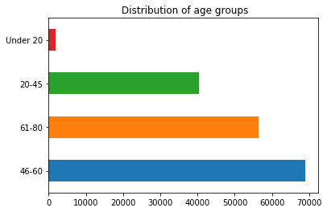

```python
merged_df['Age_Group'].value_counts().plot.barh(title=' Distribution of age groups')
```

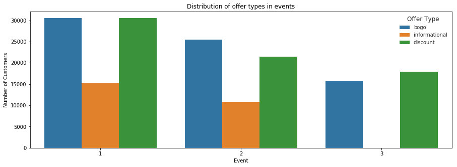

```python
plt.figure(figsize=(15, 5))
sns.countplot(x= "event", hue= "offer_type", data=merged_df)
sns.set(style="darkgrid")
plt.title('Distribution of offer types in events')
plt.ylabel('Number of Customers')
plt.xlabel('Event')
plt.legend(title='Offer Type')
```

Let's now try to answer the question above and see which age group seems to take advantage of the offers most. Because the number of customers in each group is majorly unbalanced, we'll want to normalize so that we can more accurately compare the age groups

##### Event Key:

1 = Offer Received

2 = Offer Viewed

3 = Offer Completed/Used

4 = Transaction

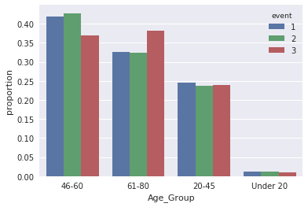

```python
x, y, hue = "Age_Group", "proportion", "event"

(merged_df[x]
 .groupby(merged_df[hue])
 .value_counts(normalize=True)
 .rename(y)
 .reset_index()
 .pipe((sns.barplot, "data"), x=x, y=y, hue=hue))
```

Looks like both the 46-60 and 61-80 age groups have the most customers actually fulfilling the offers. Let's take both of the groups and try to understand which offers they actually took advantage of

## Question 2: Of the age group(s) that completed offers, which offers did they take most advantage of?

```python
q2 = merged_df[((merged_df['Age_Group'] == '46-60') | (merged_df['Age_Group'] == '61-80')) & (merged_df['event'] == 3)]
```

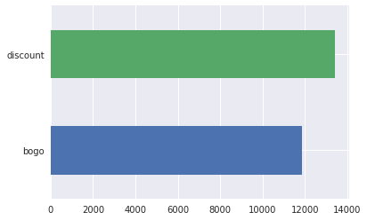

```python
# offer type distribution
q2.offer_type.value_counts().sort_values().plot(kind = 'barh')
```

Looks like it's a close call, but most of the completed offers were discounts. Let's also look at the male/female distribution of all people who completed offers

## Question 3: How many males vs females took action on offers?

```python
q3 = merged_df[merged_df['event'] == 3]
```

```python
merged_df.head()
```

|  | channels | offer_difficulty | offer_duration | offer_id | offer_type | offer_reward | email | mobile | social | web | ... | informational | event | customer_id | time | amount | reward | became_member_on | customer_gender | customer_income | Age_Group |
| --- | --- | --- | --- | --- | --- | --- | --- | --- | --- | --- | --- | --- | --- | --- | --- | --- | --- | --- | --- | --- | --- |
| 0 | [email, mobile, social] | 10 | 7 | ae264e3637204a6fb9bb56bc8210ddfd | bogo | 10 | 1 | 1 | 1 | 0 | ... | 0 | 1 | 4b0da7e80e5945209a1fdddfe813dbe0 | 0 | NaN | NaN | 2017-09-09 | M | 100000.0 | 61-80 |
| 1 | [email, mobile, social] | 10 | 7 | ae264e3637204a6fb9bb56bc8210ddfd | bogo | 10 | 1 | 1 | 1 | 0 | ... | 0 | 2 | 4b0da7e80e5945209a1fdddfe813dbe0 | 102 | NaN | NaN | 2017-09-09 | M | 100000.0 | 61-80 |
| 2 | [email, mobile, social] | 10 | 7 | ae264e3637204a6fb9bb56bc8210ddfd | bogo | 10 | 1 | 1 | 1 | 0 | ... | 0 | 1 | 4b0da7e80e5945209a1fdddfe813dbe0 | 504 | NaN | NaN | 2017-09-09 | M | 100000.0 | 61-80 |
| 3 | [email, mobile, social] | 10 | 7 | ae264e3637204a6fb9bb56bc8210ddfd | bogo | 10 | 1 | 1 | 1 | 0 | ... | 0 | 2 | 4b0da7e80e5945209a1fdddfe813dbe0 | 510 | NaN | NaN | 2017-09-09 | M | 100000.0 | 61-80 |
| 4 | [email, mobile, social] | 10 | 7 | ae264e3637204a6fb9bb56bc8210ddfd | bogo | 10 | 1 | 1 | 1 | 0 | ... | 0 | 3 | 4b0da7e80e5945209a1fdddfe813dbe0 | 510 | NaN | 10.0 | 2017-09-09 | M | 100000.0 | 61-80 |

5 rows × 22 columns

First, I really need to know. Do more males or females go to Starbucks?

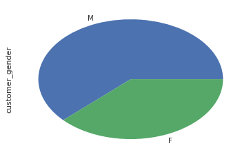

```python
merged_df.customer_gender.value_counts().plot(kind='pie')
```

Ah! So more males like to go to Starbucks! A lot of people would have argued the opposite

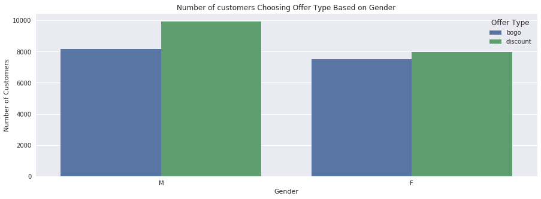

```python
plt.figure(figsize=(15, 5))
sns.countplot(x= "customer_gender", hue= "offer_type", data=q3)
sns.set(style="darkgrid")
plt.title('Number of customers Choosing Offer Type Based on Gender')
plt.ylabel('Number of Customers')
plt.xlabel('Gender')
plt.legend(title='Offer Type')
```

Looks like both males and females take more advantage of the discounted offers.

## Question 4: What channels are most likely to lead customers to complete offers?

##### Key:

1 = Offer Received

2 = Offer Viewed

3 = Offer Completed/Used

4 = Transaction

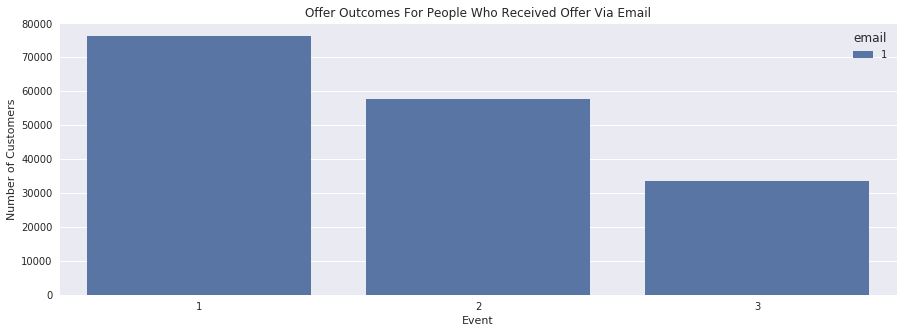

```python
plt.figure(figsize=(15, 5))
sns.countplot(x= "event", hue= "email", data=merged_df[merged_df['email']==1])
sns.set(style="darkgrid")
plt.title('Offer Outcomes For People Who Received Offer Via Email')
plt.ylabel('Number of Customers')
plt.xlabel('Event')
plt.legend(title='email')
```

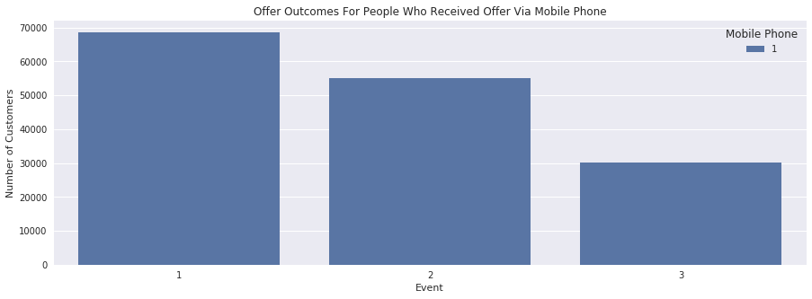

```python
plt.figure(figsize=(15, 5))
sns.countplot(x= "event", hue= "mobile", data=merged_df[merged_df['mobile']==1])
sns.set(style="darkgrid")
plt.title('Offer Outcomes For People Who Received Offer Via Mobile Phone')
plt.ylabel('Number of Customers')
plt.xlabel('Event')
plt.legend(title='Mobile Phone')
```

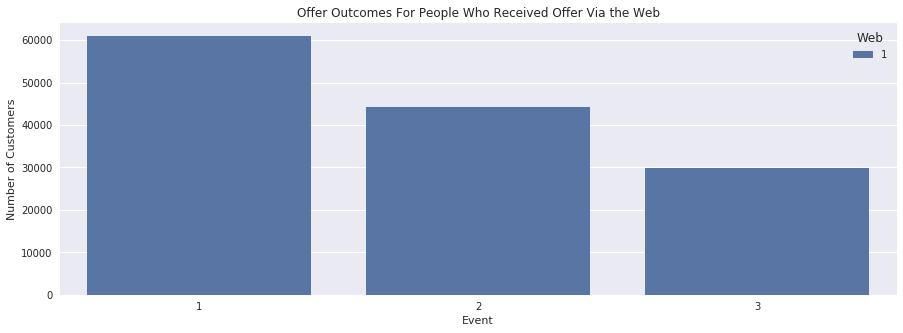

```python
plt.figure(figsize=(15, 5))
sns.countplot(x= "event", hue= "web", data=merged_df[merged_df['web']==1])
sns.set(style="darkgrid")
plt.title('Offer Outcomes For People Who Received Offer Via the Web')
plt.ylabel('Number of Customers')
plt.xlabel('Event')
plt.legend(title='Web')
```

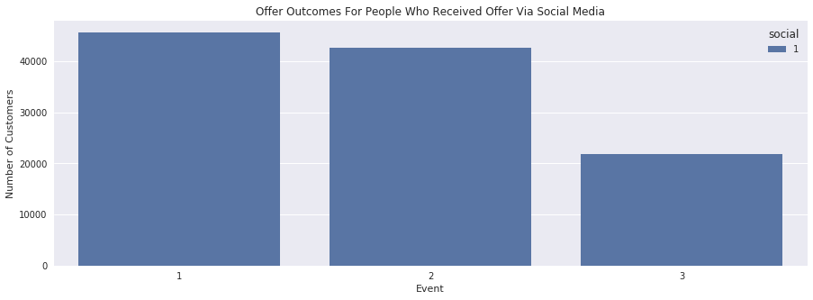

```python
plt.figure(figsize=(15, 5))
sns.countplot(x= "event", hue= "social", data=merged_df[merged_df['social']==1])
sns.set(style="darkgrid")
plt.title('Offer Outcomes For People Who Received Offer Via Social Media')
plt.ylabel('Number of Customers')
plt.xlabel('Event')
plt.legend(title='social')
```

## Question 5: Are customers influenced by the minimum spend requirement of an offer, or even by the offer amount? Do either of these metrics affect the likelihood that they will use an offer?

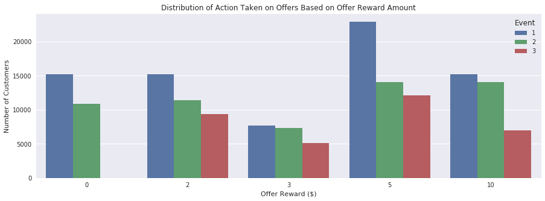

```python
plt.figure(figsize=(15, 5))
sns.countplot(x= "offer_reward", hue= "event", data=merged_df)
sns.set(style="darkgrid")
plt.title('Distribution of Action Taken on Offers Based on Offer Reward Amount')
plt.ylabel('Number of Customers')
plt.xlabel('Offer Reward ($)')
plt.legend(title='Event')
```

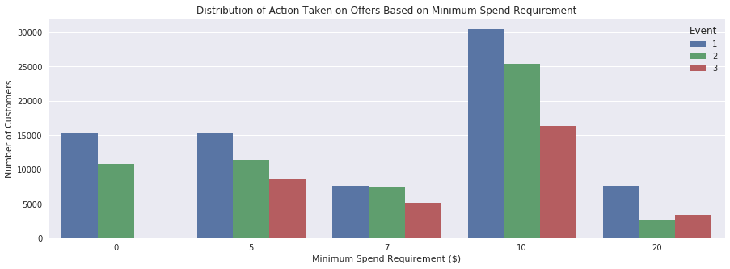

```python
plt.figure(figsize=(15, 5))
sns.countplot(x= "offer_difficulty", hue= "event", data=merged_df)
sns.set(style="darkgrid")
plt.title('Distribution of Action Taken on Offers Based on Minimum Spend Requirement')
plt.ylabel('Number of Customers')
plt.xlabel('Minimum Spend Requirement ($)')
plt.legend(title='Event')
```

Weird. We would've expected to see fewer people complete offers as offer difficulty increases. It does make sense, however, that more customers aren't viewing the offers as the offer difficulty increases

# Feature Engineering

I just wanted to add one more feature that I thought would be useful to the model

```python
merged_df.columns
```

```
Index(['channels', 'offer_difficulty', 'offer_duration', 'offer_id',
       'offer_type', 'offer_reward', 'email', 'mobile', 'social', 'web',
       'bogo', 'discount', 'informational', 'event', 'customer_id', 'time',
       'amount', 'reward', 'became_member_on', 'customer_gender',
       'customer_income', 'Age_Group'],
      dtype='object')
```

```python
## Calculate number of days since customer became a member
merged_df['became_member_on'] = pd.to_datetime(merged_df['became_member_on'])
merged_df['member_since'] = (datetime.now() - merged_df['became_member_on']).dt.days
```

```python
merged_df.columns
```

```
Index(['channels', 'offer_difficulty', 'offer_duration', 'offer_id',
       'offer_type', 'offer_reward', 'email', 'mobile', 'social', 'web',
       'bogo', 'discount', 'informational', 'event', 'customer_id', 'time',
       'amount', 'reward', 'became_member_on', 'customer_gender',
       'customer_income', 'Age_Group', 'member_since'],
      dtype='object')
```

# Modeling

Build a Machine Learning model to predict response of a customer to an offer

We'll be playing with 4 different classifiers:

1. KNN Classifier
2. Random Forest Classifier
3. Decision Tree Classifier

To improve upon the Random Forest Classifier, I'll be implementing an additional GridSearch approach with some specified parameters.

### Functions

```python
def clean_data(df):
    '''
    clean_data()
    Purpose: Removes some columns that are useless for modeling
    Inputs:
    - df: the dataframe to clean up
    Returns:
    - The same dataframe, minus the columns that were dropped
    '''
    # One hot encode categorical variables
    age_group_exploded = pd.get_dummies(df['Age_Group'].apply(pd.Series).stack()).sum(level=0)
    df = pd.concat([df, age_group_exploded], axis=1)

    gender_exploded = pd.get_dummies(df['customer_gender'].apply(pd.Series).stack()).sum(level=0)
    df = pd.concat([df, gender_exploded], axis=1)

    # impute remainin NaNs with 0
    df.fillna(0 , inplace=True)

    # remove useless columns
    cols_to_drop = ['offer_id', 'customer_id', 'channels', 'became_member_on', 'offer_type', 'Age_Group', 'customer_gender']
    cleaned_data = df.drop(cols_to_drop, axis=1)

    # Normalize data using MinMaxScaler, which normalizes datapoints between 0 and 1
    scaler = MinMaxScaler()
    numerical = ['customer_income', 'offer_difficulty', 'offer_duration', 'offer_reward', 'member_since', 'amount', 'reward', 'time']
    cleaned_data[numerical] = scaler.fit_transform(cleaned_data[numerical])

    features = cleaned_data.drop('event', axis=1)
    label = cleaned_data['event']

    return features, label
```

```python
def prepare_data(features,label):
    '''
    prepare_data()
    Purpose: Splits data into train and test datasets
    Inputs:
    - features: a df of all of the features
    - label: a df of all of the labels

    Returns:X_train, X_test, y_train and y_test dataframes
    '''

    # split into training and test sets
    X_train, X_test, y_train, y_test = train_test_split(features, label, test_size=0.20, random_state=40)

    print("Training set: {} rows".format(X_train.shape[0]))
    print("Testing set: {} rows".format(X_test.shape[0]))

    return X_train, X_test, y_train, y_test
```

```python
def build_model(classifier, gridsearch_yn):
    """
        build_model()
        Purpose: Creates a model pipeline
        Inputs:
                - classifier: the name of the classifier
                - gridsearch_yn: a boolean indicating whether or not to employ gridsearch
        Returns: A model pipeline
        TODO: Make this a little more generalizable in the future
    """

    if classifier == 'DecisionTreeClassifier':
        model = DecisionTreeClassifier(random_state = 40)

    elif classifier == 'RandomForestClassifier' or classifier == 'RandomForestClassifier_w_GridSearch':
        if gridsearch_yn:
            pipeline = Pipeline([
            ('clf', RandomForestClassifier())
            ])

            parameters = {
            'clf__n_estimators': [50, 100, 200],
            'clf__min_samples_split': [3, 4]
            }

            model = GridSearchCV(pipeline, param_grid=parameters, verbose=10)
        else:
            model = RandomForestClassifier(random_state = 40)

    elif classifier == 'KNeighborsClassifier':
        model = KNeighborsClassifier(n_neighbors = 5)

    return model
```

```python
from sklearn.metrics import accuracy_score
```

```python
def train_test_model(clf):
    """
    train_test_model()
    Purpose: Trains, Tests, and evaluates a model
    Inputs: a classifier
    Returns: a train F1 score, a test F1 score, an AUC score, and an accuracy score. Also prints confusion matrix.
    """
    train_prediction =  (clf.fit(X_train, y_train)).predict(X_train)
    test_predictions = (clf.fit(X_train, y_train)).predict(X_test)
    train_f1 =  accuracy_score(y_train, train_prediction)*100
    test_f1= fbeta_score(y_test, test_predictions, beta = 0.5, average='micro' )*100

    from sklearn.metrics import roc_curve
    from sklearn.metrics import auc

    #define metrics
    fpr, tpr, thresholds = metrics.roc_curve(y_test, test_predictions, pos_label=2)
    auc = metrics.auc(fpr, tpr)

    accuracy = accuracy_score(y_test,test_predictions)

    #Generate the confusion matrix
    cf_matrix = confusion_matrix(y_test, test_predictions)

    ax = sns.heatmap(cf_matrix, annot=True, cmap='Blues')

    ax.set_title('Seaborn Confusion Matrix with labels\n\n');
    ax.set_xlabel('\nPredicted Values')
    ax.set_ylabel('Actual Values ');

    ## Ticket labels - List must be in alphabetical order
    ax.xaxis.set_ticklabels(['False','True'])
    ax.yaxis.set_ticklabels(['False','True'])

    ## Display the visualization of the Confusion Matrix.
    plt.show()


    return train_f1, test_f1, auc, accuracy
```

### Implementation

```python
print("Cleaning Data...")
try:
    features, label = clean_data(merged_df)
    print("Cleaning Successful!")
except:
    print("Clean Failed.")
```

```
Cleaning Data...
Cleaning Successful!
```

```python
print("Pre-Processing Data...")
try:
    X_train, X_test, y_train, y_test = prepare_data(features, label)
    print("Pre-Processing Successful!")
except:
    print("Pre-Processing Failed.")
```

```
Pre-Processing Data...
Training set: 134064 rows
Testing set: 33517 rows
Pre-Processing Successful!
```

```
Building DecisionTreeClassifier Model...
Build Successful!
Training DecisionTreeClassifier Model...
0.849001998986
```

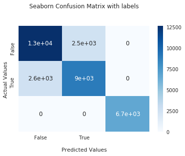

```
Training Successful!
---------------------------------
Building KNeighborsClassifier Model...
Build Successful!
Training KNeighborsClassifier Model...
0.638989169675
```

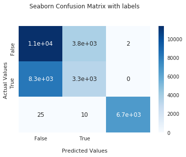

```
Training Successful!
---------------------------------
Building RandomForestClassifier Model...
Build Successful!
Training RandomForestClassifier Model...
0.733627711311
```

[figure not shown]

```
Training Successful!
---------------------------------
Building RandomForestClassifier_w_GridSearch Model...
Build Successful!
Training RandomForestClassifier_w_GridSearch Model...
Fitting 3 folds for each of 6 candidates, totalling 18 fits
[CV] clf__min_samples_split=3, clf__n_estimators=50 ..................
[CV]  clf__min_samples_split=3, clf__n_estimators=50, score=0.8011814988028374, total=   6.8s
[CV] clf__min_samples_split=3, clf__n_estimators=50 ..................
```

```
[Parallel(n_jobs=1)]: Done   1 out of   1 | elapsed:    8.1s remaining:    0.0s
```

```
[CV]  clf__min_samples_split=3, clf__n_estimators=50, score=0.7869226638023631, total=   6.5s
[CV] clf__min_samples_split=3, clf__n_estimators=50 ..................
```

```
[Parallel(n_jobs=1)]: Done   2 out of   2 | elapsed:   15.9s remaining:    0.0s
```

```
[CV]  clf__min_samples_split=3, clf__n_estimators=50, score=0.7921319399377895, total=   7.0s
[CV] clf__min_samples_split=3, clf__n_estimators=100 .................
```

```
[Parallel(n_jobs=1)]: Done   3 out of   3 | elapsed:   24.2s remaining:    0.0s
```

```
[CV]  clf__min_samples_split=3, clf__n_estimators=100, score=0.7898811788135783, total=  13.7s
[CV] clf__min_samples_split=3, clf__n_estimators=100 .................
```

```
[Parallel(n_jobs=1)]: Done   4 out of   4 | elapsed:   40.6s remaining:    0.0s
```

```
[CV]  clf__min_samples_split=3, clf__n_estimators=100, score=0.7933897243107769, total=  13.8s
[CV] clf__min_samples_split=3, clf__n_estimators=100 .................
```

```
[Parallel(n_jobs=1)]: Done   5 out of   5 | elapsed:   56.9s remaining:    0.0s
```

```
[CV]  clf__min_samples_split=3, clf__n_estimators=100, score=0.7931836999574821, total=  13.7s
[CV] clf__min_samples_split=3, clf__n_estimators=200 .................
```

```
[Parallel(n_jobs=1)]: Done   6 out of   6 | elapsed:  1.2min remaining:    0.0s
```

```
[CV]  clf__min_samples_split=3, clf__n_estimators=200, score=0.7942670455816868, total=  27.3s
[CV] clf__min_samples_split=3, clf__n_estimators=200 .................
```

```
[Parallel(n_jobs=1)]: Done   7 out of   7 | elapsed:  1.8min remaining:    0.0s
```

```
[CV]  clf__min_samples_split=3, clf__n_estimators=200, score=0.7949113856068744, total=  26.7s
[CV] clf__min_samples_split=3, clf__n_estimators=200 .................
```

```
[Parallel(n_jobs=1)]: Done   8 out of   8 | elapsed:  2.3min remaining:    0.0s
```

```
[CV]  clf__min_samples_split=3, clf__n_estimators=200, score=0.7906102445901493, total=  27.0s
[CV] clf__min_samples_split=4, clf__n_estimators=50 ..................
```

```
[Parallel(n_jobs=1)]: Done   9 out of   9 | elapsed:  2.8min remaining:    0.0s
```

[output not shown]

```
[Parallel(n_jobs=1)]: Done  18 out of  18 | elapsed:  5.6min finished
```

```
Fitting 3 folds for each of 6 candidates, totalling 18 fits
[CV] clf__min_samples_split=3, clf__n_estimators=50 ..................
[CV]  clf__min_samples_split=3, clf__n_estimators=50, score=0.7955649041151066, total=   6.8s
[CV] clf__min_samples_split=3, clf__n_estimators=50 ..................
```

```
[Parallel(n_jobs=1)]: Done   1 out of   1 | elapsed:    8.2s remaining:    0.0s
```

```
[CV]  clf__min_samples_split=3, clf__n_estimators=50, score=0.7934121016827784, total=   6.8s
[CV] clf__min_samples_split=3, clf__n_estimators=50 ..................
```

```
[Parallel(n_jobs=1)]: Done   2 out of   2 | elapsed:   16.2s remaining:    0.0s
```

```
[CV]  clf__min_samples_split=3, clf__n_estimators=50, score=0.7929375433571285, total=   6.6s
[CV] clf__min_samples_split=3, clf__n_estimators=100 .................
```

```
[Parallel(n_jobs=1)]: Done   3 out of   3 | elapsed:   24.1s remaining:    0.0s
```

```
[CV]  clf__min_samples_split=3, clf__n_estimators=100, score=0.7938195081563696, total=  13.7s
[CV] clf__min_samples_split=3, clf__n_estimators=100 .................
```

```
[Parallel(n_jobs=1)]: Done   4 out of   4 | elapsed:   40.4s remaining:    0.0s
```

```
[CV]  clf__min_samples_split=3, clf__n_estimators=100, score=0.7927407805227354, total=  13.2s
[CV] clf__min_samples_split=3, clf__n_estimators=100 .................
```

```
[Parallel(n_jobs=1)]: Done   5 out of   5 | elapsed:   56.4s remaining:    0.0s
```

```
[CV]  clf__min_samples_split=3, clf__n_estimators=100, score=0.7961152012889655, total=  13.4s
[CV] clf__min_samples_split=3, clf__n_estimators=200 .................
```

```
[Parallel(n_jobs=1)]: Done   6 out of   6 | elapsed:  1.2min remaining:    0.0s
```

```
[CV]  clf__min_samples_split=3, clf__n_estimators=200, score=0.7936628700575086, total=  27.9s
[CV] clf__min_samples_split=3, clf__n_estimators=200 .................
```

```
[Parallel(n_jobs=1)]: Done   7 out of   7 | elapsed:  1.8min remaining:    0.0s
```

```
[CV]  clf__min_samples_split=3, clf__n_estimators=200, score=0.7965896885069818, total=  27.1s
[CV] clf__min_samples_split=3, clf__n_estimators=200 .................
```

```
[Parallel(n_jobs=1)]: Done   8 out of   8 | elapsed:  2.3min remaining:    0.0s
```

```
[CV]  clf__min_samples_split=3, clf__n_estimators=200, score=0.7984648779287041, total=  27.1s
[CV] clf__min_samples_split=4, clf__n_estimators=50 ..................
```

```
[Parallel(n_jobs=1)]: Done   9 out of   9 | elapsed:  2.8min remaining:    0.0s
```

[output not shown]

```
[Parallel(n_jobs=1)]: Done  18 out of  18 | elapsed:  5.6min finished
```

```
0.786108541934
```

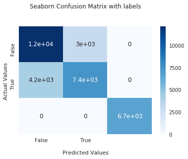

```
Training Successful!
---------------------------------
```

```python
classifiers = {'DecisionTreeClassifier': False, 'KNeighborsClassifier': False, 'RandomForestClassifier': False, 'RandomForestClassifier_w_GridSearch': True}
models = {'model_name': [], 'train_f1_score': [], 'test_f1_score': [], 'auc':[], 'accuracy':[]}

for clf_name, gridsearch_yn in classifiers.items():
    print("Building {} Model...".format(clf_name))
    try:
        model = build_model(clf_name, gridsearch_yn)
        print("Build Successful!")
    except:
        print("Build Failed.")
        continue

    print("Training {} Model...".format(clf_name))
    try:
        train_f1, test_f1, auc, accuracy = train_test_model(model)

        # append to models dict for comparison later
        if gridsearch_yn:
            models['model_name'].append(clf_name + ' w/ GridSearch CV')
        else:
            models['model_name'].append(clf_name)

        models['train_f1_score'].append(train_f1)
        models['test_f1_score'].append(test_f1)
        models['auc'].append(auc)
        models['accuracy'].append(accuracy)

        print("Training Successful!")
    except:
        print("Training Failed.")
        continue

    print('---------------------------------')

model_comp = pd.DataFrame(models)
```

```python
model_comp
```

|  | model_name | train_f1_score | test_f1_score | auc | accuracy |
| --- | --- | --- | --- | --- | --- |
| 0 | DecisionTreeClassifier | 93.925289 | 84.900200 | 0.559467 | 0.849002 |
| 1 | KNeighborsClassifier | 78.699726 | 63.898917 | 0.360363 | 0.638989 |
| 2 | RandomForestClassifier | 93.256206 | 73.362771 | 0.451599 | 0.733628 |
| 3 | RandomForestClassifier_w_GridSearch w/ GridSea... | 93.798484 | 78.610854 | 0.500113 | 0.786109 |

Of the four classifier variations tested, it looks like the Decision Tree classifier performs the best, with an F1 Validation score of 84.9. The RandomForestClassifier also performs very well, and it also makes sense that the RFC with GridSearch performs better than the one without. Because the problem that we’re trying to solve isn’t very high stakes, a moderate F1 score is sufficient enough for us to classify whether a customer will respond to an offer or not.

```python
from subprocess import call
call(['python', '-m', 'nbconvert', 'Starbucks_Capstone_Notebook.ipynb'])
```

```
255
```

Link to Medium Blog for more details: https://medium.com/@nataliegilbert42/how-data-can-allow-us-to-predict-a-starbucks-customers-response-to-an-offer-b0ac42d33fb7

fin